Have a few things here:

1. plots
2. linear model (dropping mixed terms)
3. mean subtracted

# ADI plots

First, we consider boxplot of adi by weeks premature status

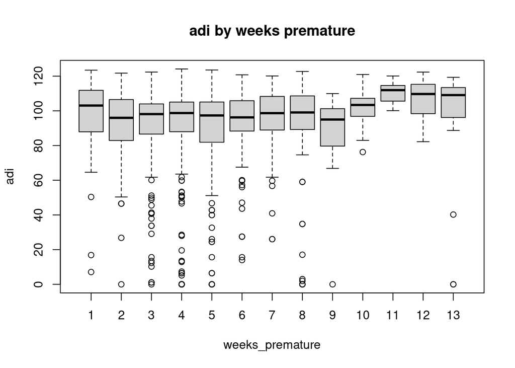

Or even distribution of ADI by preterm status. Noteably, the IQR of the regular term is slightly wider

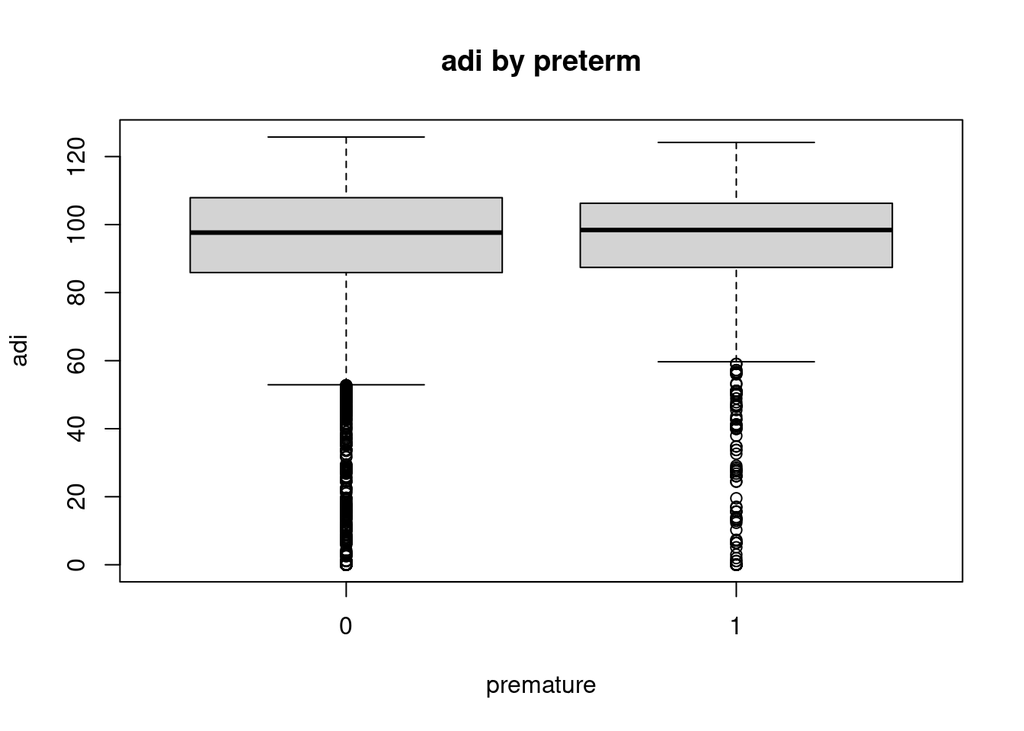

In terms of these two groups, though, it’s also worth noting that there is not much difference in terms of thickness. Here is the distribution of thickness values with regular term in the first column, and broken down by weeks in the remaining ones

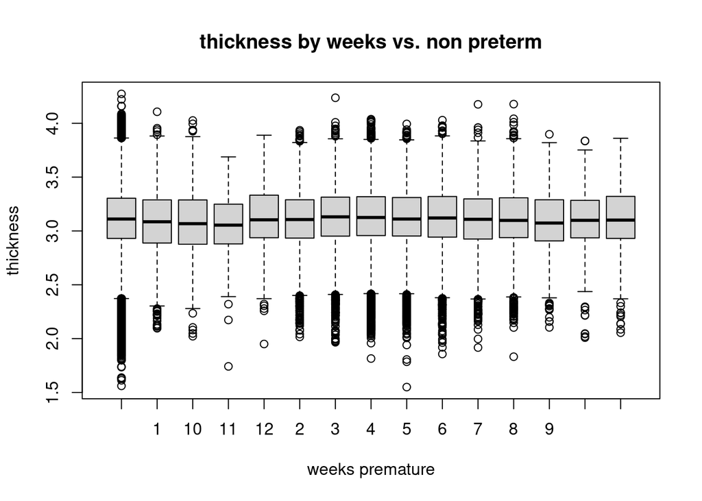

Two more plots to consider. First, we have distribution of ADI by parent education (this is highest parent ed, rather than mean education)

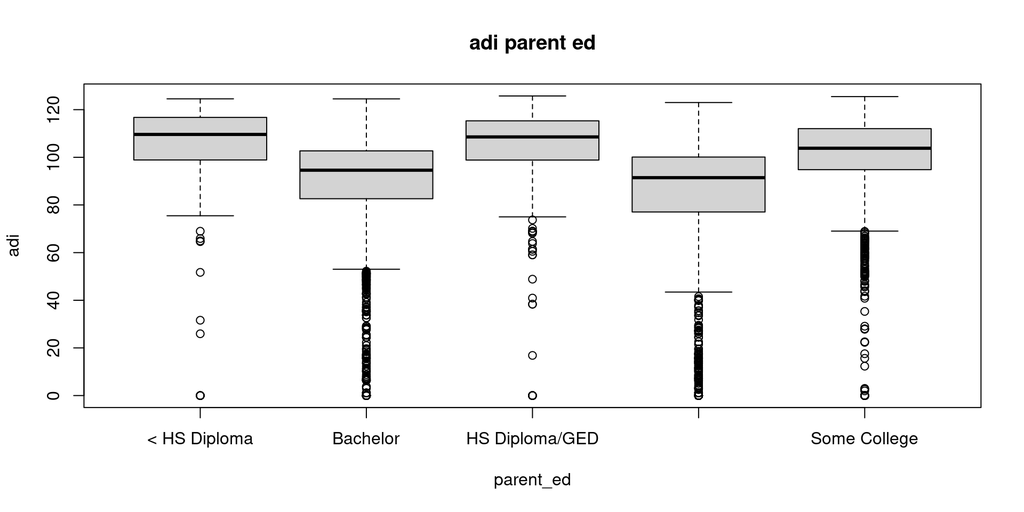

However, in terms of thickness (for all sites) the groups are virtually indistinguishable

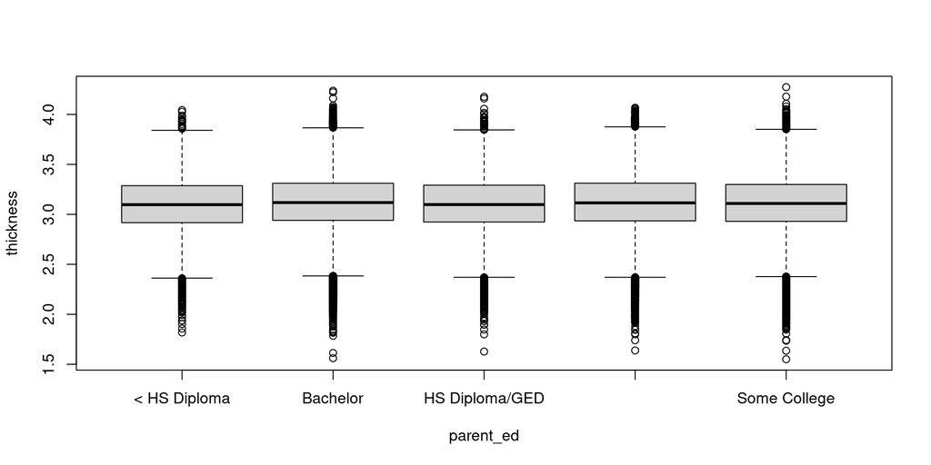

## Statistics for regions

In interpreting the values from the models, helpful to know the mean and sd in thickness of each region

|  | mean | sd |
| --- | --- | --- |
| destrieux_g.front.inf.opercular.lh | 3.1005 | 0.17648 |
| destrieux_g.front.inf.opercular.rh | 3.1120 | 0.17581 |
| destrieux_g.front.inf.orbital.lh | 3.2123 | 0.23877 |
| destrieux_g.front.inf.orbital.rh | 3.1710 | 0.25586 |
| destrieux_g.front.inf.triangul.lh | 3.0419 | 0.19033 |
| destrieux_g.front.inf.triangul.rh | 3.0140 | 0.22958 |
| destrieux_g.front.middle.lh | 3.0017 | 0.19225 |
| destrieux_g.front.middle.rh | 2.9842 | 0.20101 |
| destrieux_g.pariet.inf.supramar.lh | 3.0306 | 0.22687 |
| destrieux_g.pariet.inf.supramar.rh | 3.0343 | 0.24652 |
| destrieux_g.temporal.middle.lh | 3.3552 | 0.23814 |
| destrieux_g.temporal.middle.rh | 3.3856 | 0.24234 |
| destrieux_g.temp.sup.lateral.lh | 3.3757 | 0.26556 |
| destrieux_g.temp.sup.lateral.rh | 3.3873 | 0.25198 |
| destrieux_s.temporal.transverse.lh | 2.6372 | 0.31070 |
| destrieux_s.temporal.transverse.rh | 2.7720 | 0.30088 |

# Summaries

Presented here are two sets of ADI models

1. The first is standard mixed model, the second is simple linear regression (no random terms)
2. Adi has been replaced with adi_m, not standardized, but has the mean value subtracted (so mean is zero)

## Mixed Model

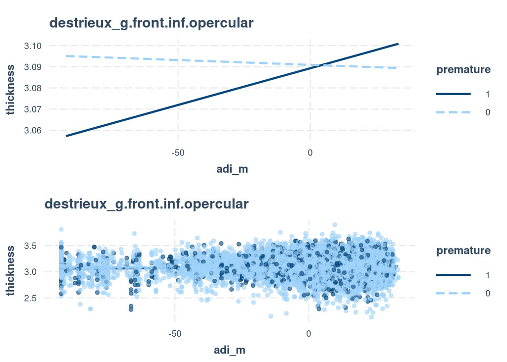

destrieux_g.front.inf.opercular

|  | Estimate | Std. Error | 95%L | 95%U | p-val |
| --- | --- | --- | --- | --- | --- |
| (Intercept) | 3.1656 | 0.0255 | 3.1156 | 3.2156 | 0.0000 |
| femaleyes | 0.0219 | 0.0026 | 0.0169 | 0.0269 | 0.0000 |
| premature | -0.0016 | 0.0035 | -0.0084 | 0.0052 | 0.6411 |
| adi_m | 0.0000 | 0.0001 | -0.0002 | 0.0001 | 0.5055 |
| age | -0.0006 | 0.0002 | -0.0010 | -0.0003 | 0.0003 |
| premature:adi_m | 0.0004 | 0.0001 | 0.0001 | 0.0007 | 0.0050 |

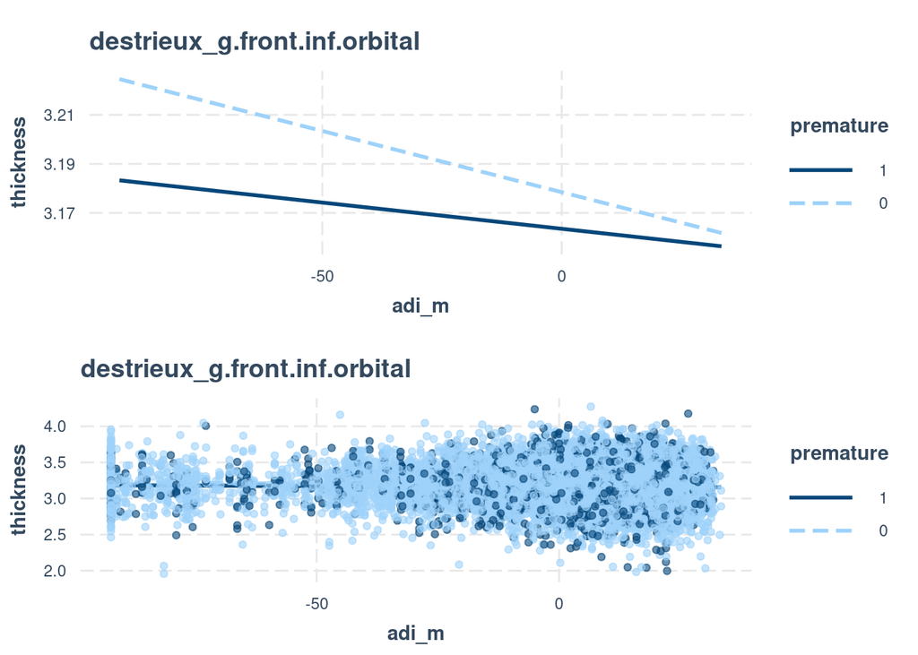

destrieux_g.front.inf.orbital

|  | Estimate | Std. Error | 95%L | 95%U | p-val |
| --- | --- | --- | --- | --- | --- |
| (Intercept) | 3.3386 | 0.0383 | 3.2635 | 3.4137 | 0.0000 |
| femaleyes | 0.0273 | 0.0038 | 0.0200 | 0.0347 | 0.0000 |
| premature | -0.0149 | 0.0051 | -0.0248 | -0.0050 | 0.0032 |
| adi_m | -0.0005 | 0.0001 | -0.0007 | -0.0003 | 0.0000 |
| age | -0.0013 | 0.0003 | -0.0018 | -0.0008 | 0.0000 |
| premature:adi_m | 0.0003 | 0.0002 | -0.0001 | 0.0007 | 0.1630 |

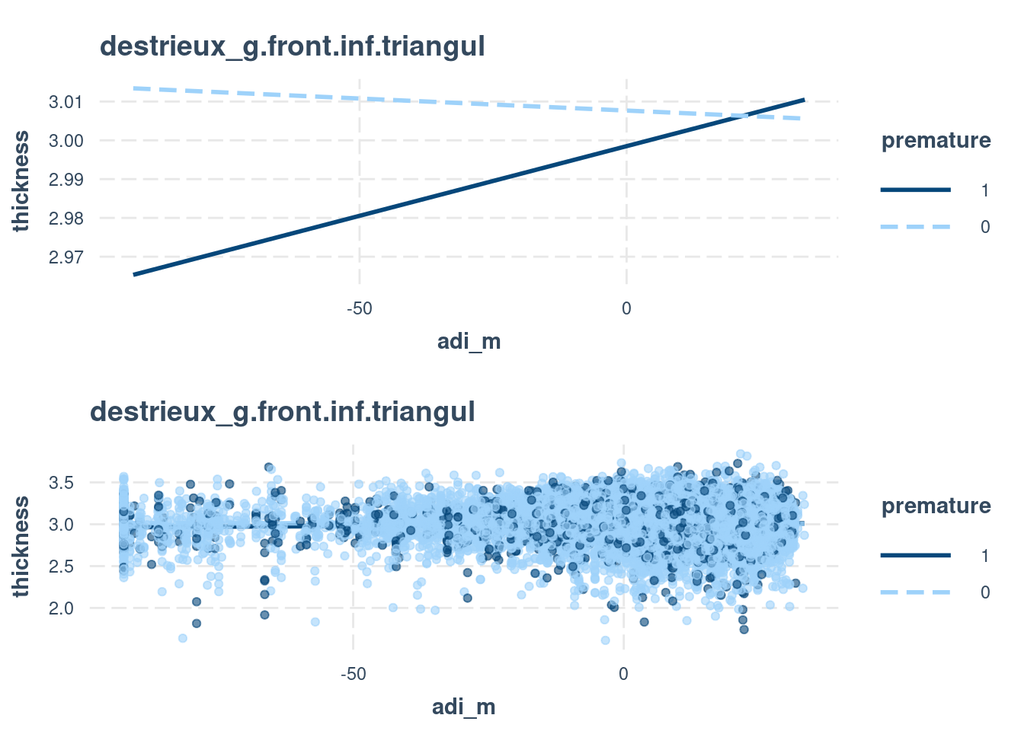

destrieux_g.front.inf.triangul

|  | Estimate | Std. Error | 95%L | 95%U | p-val |
| --- | --- | --- | --- | --- | --- |
| (Intercept) | 3.1546 | 0.0338 | 3.0884 | 3.2208 | 0.0000 |
| femaleyes | 0.0318 | 0.0030 | 0.0259 | 0.0377 | 0.0000 |
| premature | -0.0092 | 0.0040 | -0.0171 | -0.0012 | 0.0235 |
| adi_m | -0.0001 | 0.0001 | -0.0002 | 0.0001 | 0.4346 |
| age | -0.0012 | 0.0002 | -0.0016 | -0.0008 | 0.0000 |
| premature:adi_m | 0.0004 | 0.0002 | 0.0001 | 0.0007 | 0.0099 |

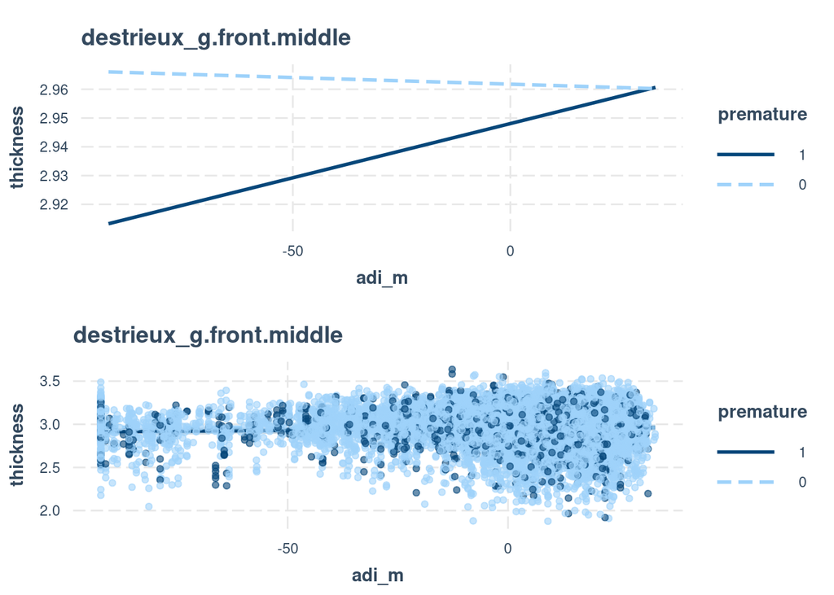

destrieux_g.front.middle

|  | Estimate | Std. Error | 95%L | 95%U | p-val |
| --- | --- | --- | --- | --- | --- |
| (Intercept) | 3.0823 | 0.0344 | 3.0150 | 3.1497 | 0.0000 |
| femaleyes | 0.0312 | 0.0026 | 0.0262 | 0.0363 | 0.0000 |
| premature | -0.0137 | 0.0035 | -0.0205 | -0.0069 | 0.0001 |
| adi_m | 0.0000 | 0.0001 | -0.0002 | 0.0001 | 0.4995 |
| age | -0.0010 | 0.0002 | -0.0014 | -0.0007 | 0.0000 |
| premature:adi_m | 0.0004 | 0.0001 | 0.0001 | 0.0007 | 0.0026 |

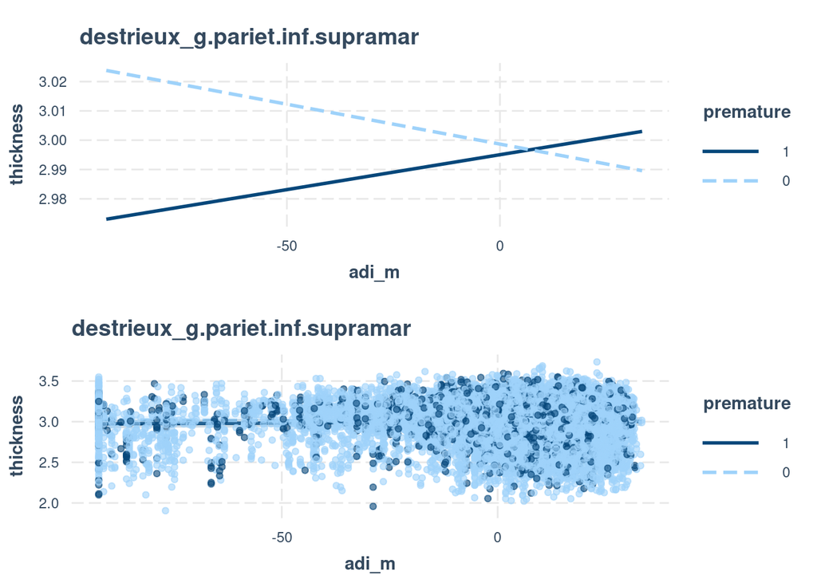

destrieux_g.pariet.inf.supramar

|  | Estimate | Std. Error | 95%L | 95%U | p-val |
| --- | --- | --- | --- | --- | --- |
| (Intercept) | 3.0924 | 0.0437 | 3.0069 | 3.1780 | 0.0000 |
| femaleyes | 0.0301 | 0.0027 | 0.0249 | 0.0354 | 0.0000 |
| premature | -0.0036 | 0.0036 | -0.0107 | 0.0034 | 0.3144 |
| adi_m | -0.0003 | 0.0001 | -0.0004 | -0.0001 | 0.0001 |
| age | -0.0008 | 0.0002 | -0.0011 | -0.0004 | 0.0000 |
| premature:adi_m | 0.0005 | 0.0001 | 0.0002 | 0.0008 | 0.0004 |

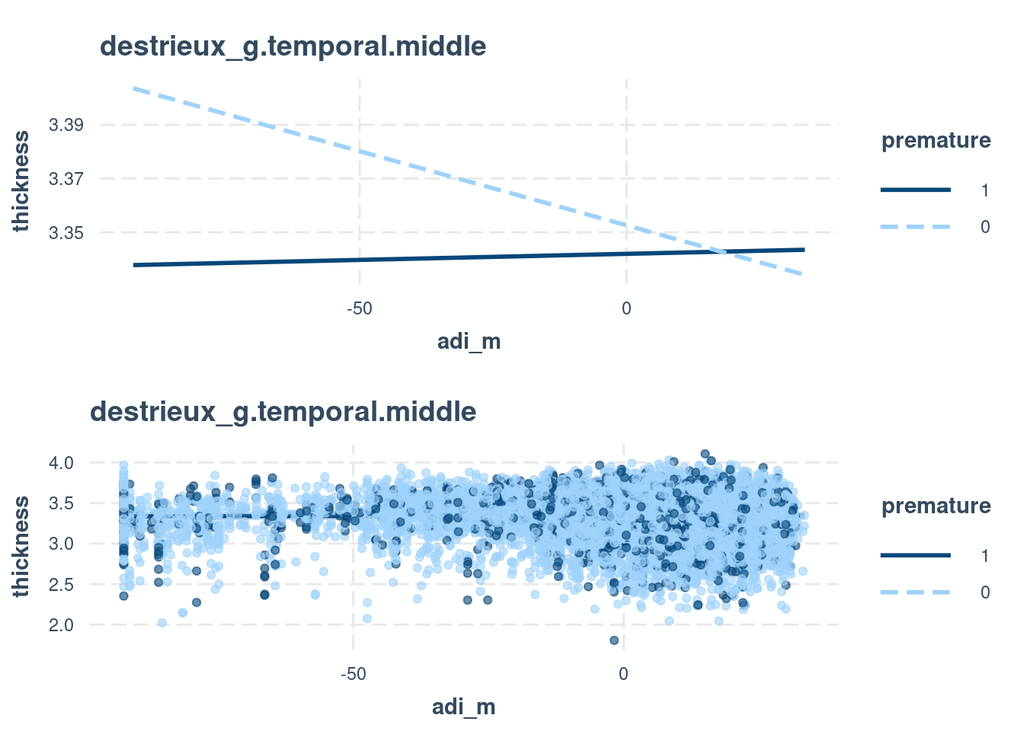

destrieux_g.temporal.middle

|  | Estimate | Std. Error | 95%L | 95%U | p-val |
| --- | --- | --- | --- | --- | --- |
| (Intercept) | 3.4465 | 0.0423 | 3.3636 | 3.5294 | 0.0000 |
| femaleyes | 0.0145 | 0.0031 | 0.0084 | 0.0205 | 0.0000 |
| premature | -0.0106 | 0.0042 | -0.0187 | -0.0025 | 0.0108 |
| adi_m | -0.0006 | 0.0001 | -0.0007 | -0.0004 | 0.0000 |
| age | -0.0008 | 0.0002 | -0.0012 | -0.0004 | 0.0002 |
| premature:adi_m | 0.0006 | 0.0002 | 0.0003 | 0.0009 | 0.0004 |

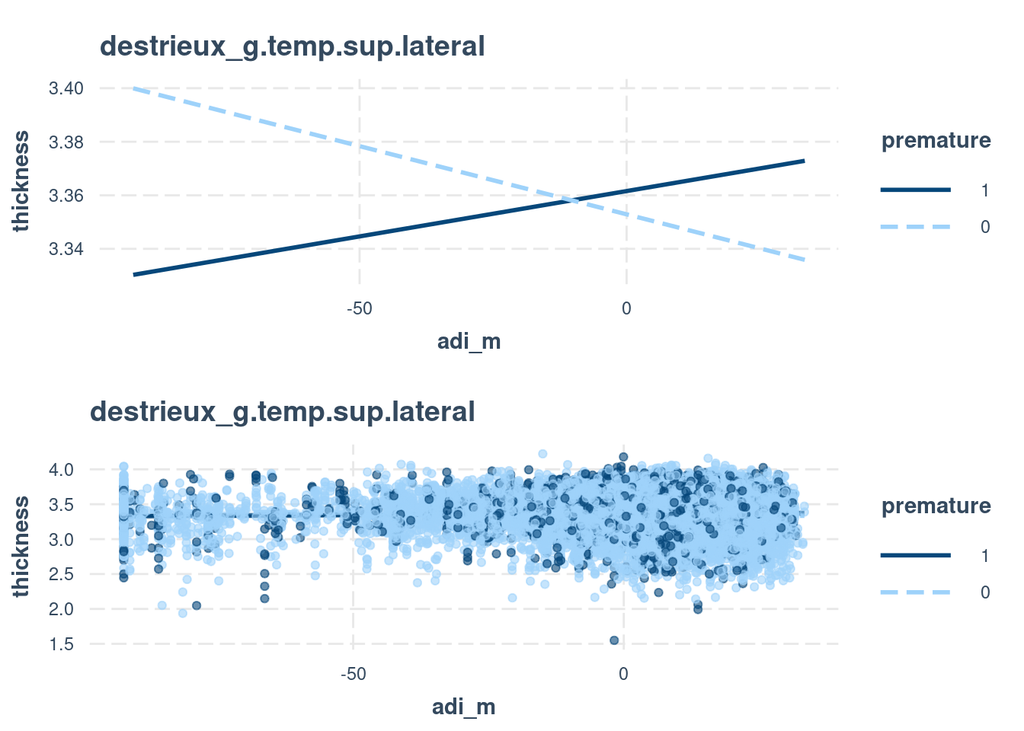

destrieux_g.temp.sup.lateral

|  | Estimate | Std. Error | 95%L | 95%U | p-val |
| --- | --- | --- | --- | --- | --- |
| (Intercept) | 3.3537 | 0.0409 | 3.2736 | 3.4339 | 0.0000 |
| femaleyes | 0.0352 | 0.0034 | 0.0285 | 0.0419 | 0.0000 |
| premature | 0.0087 | 0.0046 | -0.0004 | 0.0177 | 0.0597 |
| adi_m | -0.0005 | 0.0001 | -0.0007 | -0.0003 | 0.0000 |
| age | 0.0000 | 0.0002 | -0.0005 | 0.0004 | 0.9750 |
| premature:adi_m | 0.0008 | 0.0002 | 0.0005 | 0.0012 | 0.0000 |

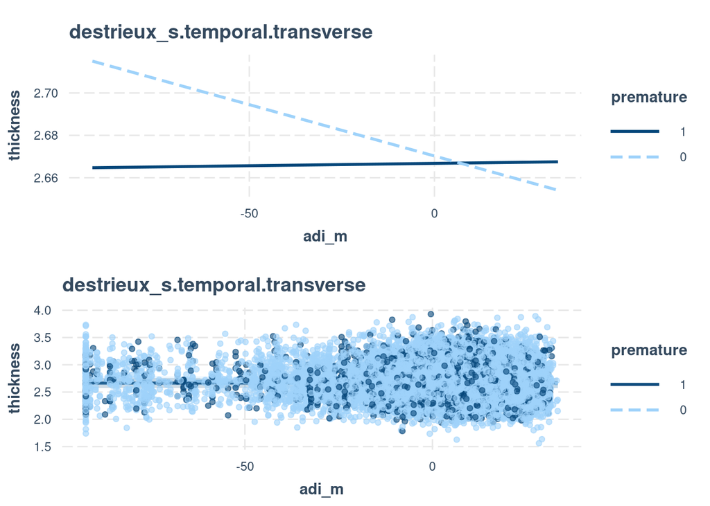

destrieux_s.temporal.transverse

[output not shown]

## LM

```
## [1] "smri_thick_cort.destrieux_g.front.inf.opercular"
##
## Call:
## lm(formula = form_x, data = x)
##
## Residuals:
##     Min      1Q  Median      3Q     Max
## -0.9679 -0.1089  0.0028  0.1130  0.7856
##
## Coefficients:
##                          Estimate Std. Error t value             Pr(>|t|)
## (Intercept)             3.0519734  0.0253630  120.33 < 0.0000000000000002 ***
## race_ethnicityBlack     0.1049156  0.0139530    7.52    0.000000000000058 ***
## race_ethnicityHispanic  0.0494478  0.0138980    3.56              0.00037 ***
## race_ethnicityOther     0.0501504  0.0139225    3.60              0.00032 ***
## race_ethnicityWhite     0.0688425  0.0134118    5.13    0.000000288393550 ***
## femaleyes               0.0209033  0.0027119    7.71    0.000000000000014 ***
## premature               0.0081836  0.0034459    2.37              0.01757 *
## adi_m                   0.0000167  0.0000628    0.27              0.79006
## age                    -0.0002187  0.0001813   -1.21              0.22775
## premature:adi_m         0.0004138  0.0001470    2.81              0.00489 **
## ---
## Signif. codes:  0 '***' 0.001 '**' 0.01 '*' 0.05 '.' 0.1 ' ' 1
##
## Residual standard error: 0.175 on 16704 degrees of freedom
## Multiple R-squared:  0.0151, Adjusted R-squared:  0.0145
## F-statistic: 28.4 on 9 and 16704 DF,  p-value: <0.0000000000000002
##
## ------------------------------------------------------------------------
## [1] "smri_thick_cort.destrieux_g.front.inf.orbital"
##
## Call:
## lm(formula = form_x, data = x)
##
## Residuals:
##     Min      1Q  Median      3Q     Max
## -1.2665 -0.1531  0.0006  0.1548  1.0898
##
## Coefficients:
##                          Estimate Std. Error t value             Pr(>|t|)
```

[output cut: 177 more lines]

```
## race_ethnicityOther     0.001197   0.024723    0.05              0.9614
## race_ethnicityWhite     0.021005   0.023816    0.88              0.3778
## femaleyes               0.071627   0.004816   14.87 <0.0000000000000002 ***
## premature              -0.001631   0.006119   -0.27              0.7898
## adi_m                  -0.000125   0.000112   -1.12              0.2634
## age                    -0.001079   0.000322   -3.35              0.0008 ***
## premature:adi_m         0.000422   0.000261    1.61              0.1064
## ---
## Signif. codes:  0 '***' 0.001 '**' 0.01 '*' 0.05 '.' 0.1 ' ' 1
##
## Residual standard error: 0.311 on 16704 degrees of freedom
## Multiple R-squared:  0.0164, Adjusted R-squared:  0.0159
## F-statistic: 30.9 on 9 and 16704 DF,  p-value: <0.0000000000000002
##
## ------------------------------------------------------------------------
```